# QFunC Mixed Model

Simulation results

## Model

$J$ regions, $L_j$ voxels in region $j$, $M$ time points.

$$X_{jlm} = \mu_j + \eta_{jm} + \gamma_{j\ell m} + \epsilon_{j\ell m}$$

For a region $j$,

- $\mu_j$ is the overall mean
- $\eta_{jm}$ is the common mean-zero signal shared by all voxels
- $\gamma_{j\ell m}$ is the spatiotemporal signal across voxels
- $\epsilon_{j\ell m}$ is i.i.d. noise

$$X_{j\ell m} = \mu_j + \eta_{jm} + \gamma_{j\ell m} + \epsilon_{j\ell m}$$

$$\begin{align}
\label{eq:SpaTempKern}
(C_j)_{ll'} &= K(\big\lVert{v_{j\ell} - v_{j\ell'}}\big\rVert; \nu_j, \phi_j) \nonumber \\
(B_j)_{mm'} &= k_{\gamma_j}H(|m - m'|; \tau_{\gamma_j}) + \sigma^2_{\gamma_j}\delta_{mm'} \nonumber \\
(A)_{mm'} &= H(|m - m'|; \tau_\eta) + \sigma^2_\eta \delta_{mm'} \\
\end{align}$$

$$\begin{align}
\quad R &= \begin{pmatrix}
1 & \rho_{12} & \cdots & \rho_{1J} \\
\rho_{12} & 1 & \ddots & \cdots \\
\vdots & \ddots & \ddots & \ddots \\
\rho_{J1} & \vdots & \ddots & 1
\end{pmatrix},
\Omega = SRS, \quad S = \operatorname{diag}(k_{\eta_1}^{1/2}, \dotsc, k_{\eta_J}^{1/2}) \\
\label{eq:varMats}
\operatorname{Var}(\epsilon) &= \Sigma_\epsilon :=
\operatorname{diag}(\sigma^2_{\epsilon_1} I_{ML_1},\dotsc , \sigma^2_{\epsilon_J} I_{ML_J}) \\
\operatorname{Var}(\gamma) &= \Sigma_\epsilon^{1/2}\Lambda \Sigma_\epsilon^{1/2},
\quad \Lambda = \operatorname{diag}(C_1 \otimes B_1,\dotsc, C_J \otimes B_J) \\
\operatorname{Var}(\eta) &= (\tilde{\Sigma}_\epsilon^{1/2}\Omega \tilde{\Sigma}_\epsilon^{1/2})\otimes A
\end{align}$$

Stage 1 parameters: $(k_{\gamma_j}, \sigma^2_{\gamma_j}, \tau_{\gamma_j}, \phi_j, \sigma^2_{\epsilon_j})$

Stage 2 parameters: $(\rho_{jj'}, k_{\eta_j}, k_{\eta_{j'}}, \tau_\eta, \sigma^2_{\eta})$

Need to choose suitable parameters for our simulations.

## Simulation setting

We consider various simulation settings to evaluate the performance of our method.

- Correct specification
- Spatial and temporal misspecification

For each simulation setting, we generate data from three regions using real voxel coordinates and $60$ time points.

The three regions contain $41$, $25$, and $77$ voxels.

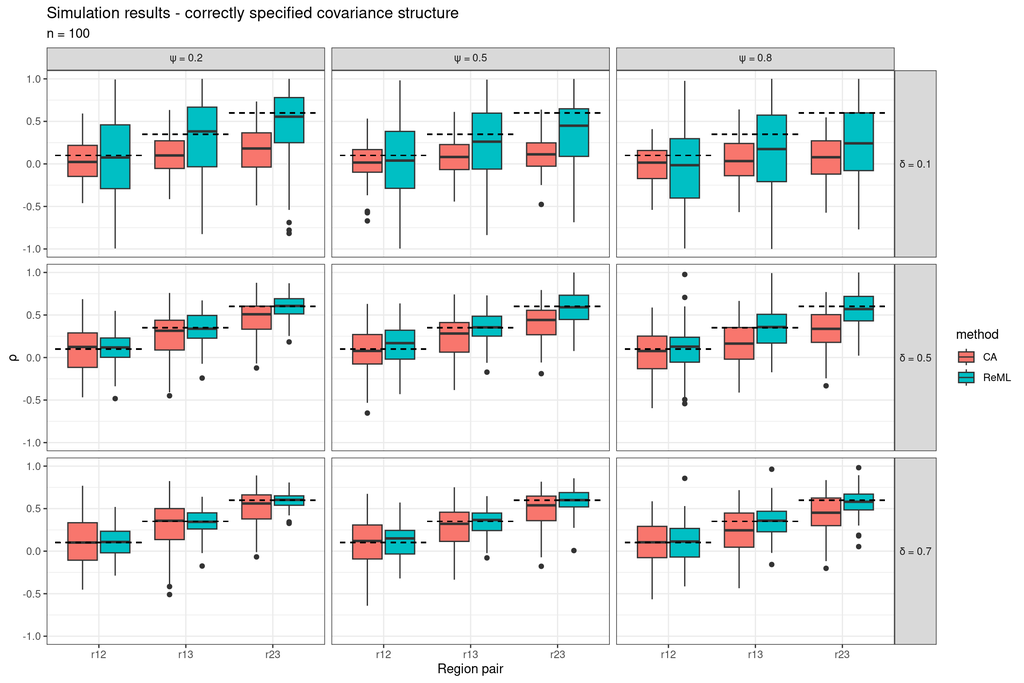

Correct specification

The average of intra-regional correlations is given by
$$\alpha_j = \frac{1}{L_j^2} \sum_{\ell, \ell'} \operatorname{Cor}(Y_j(v_{j\ell, t_m}), Y_j(v_{j\ell'}, t_m))$$
We can write
$$\alpha_j = \delta_j + (1-\delta_j)\psi_j$$
where

- $\delta_j = \frac{k_{\eta_j}(1+\sigma^2_\eta)}{k_{\eta_j}(1+\sigma^2_\eta) + (k_{\gamma_j} + \sigma^2_{\gamma_j})}$ is the variance of $\eta_j$ relative to $Y_j(v, t)$
- $\psi_j = \frac{1}{L_j^2} \sum_{\ell, \ell'} K(\big\lVert{v_{j\ell} - v_{j\ell'}}\big\rVert; \nu_j, \phi_j)$ is the average intra-regional spatial covariance
- Large $\delta_j$ means strong common signal relative to voxel-level signal. Easier to estimate $\rho$.
- For fixed $\delta_j$, larger $\psi_j$ means stronger spatial signal.

In simulated data, we choose parameters such that $\delta_j = 0.1, 0.5, 0.7$ and $\psi_j = 0.2, 0.5, 0.8$.

## Misspecification

We consider both temporal and spatial misspecification.

- Temporal misspecification: $A$ and $B_j$
  - $AR(2)$ with $\phi_1 = 0.4$ and $\phi_2 = 0.3$
  - Fractional Gaussian noise with $H = 0.7$
  - Pass raw signal through wavelet transformation to get 60 coefficients
- Spatial misspecification: $C_j$ [Castruccio et al. (2018)]
  - Anisotropic Matérn
  - Partition region $j$ into two subregions with centroids $v_{j1}^*, v_{j2}^*$.
  - Consider $R = \operatorname{diag}(1, 1.2, 1.5)$.
  - $[C_j]_{\ell\ell'} = \sum_{s=1}^2 w_{s\ell} w_{s\ell'} K(\big\lVert{R(v_{j\ell} - v_{j\ell'})}\big\rVert; \nu_j, \phi_j)$
  - $w_{sl} = (\big\lVert{v_{j\ell} - v_{js^*}}\big\rVert)^{-1}$ is the inverse distance to the centroid.

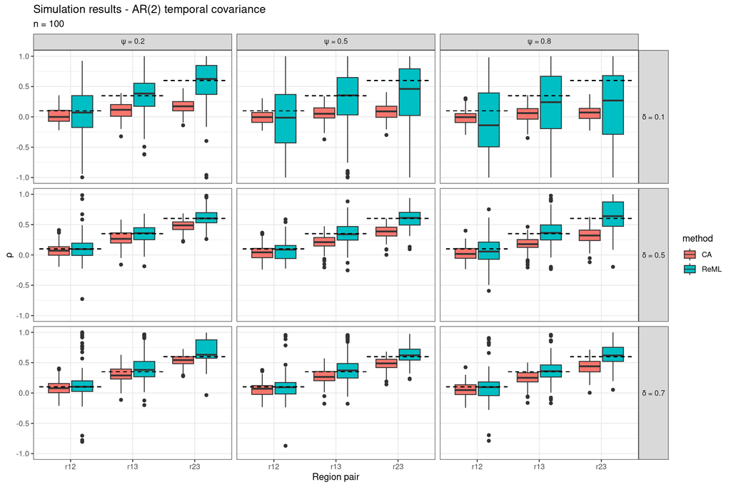

Temporal misspecification

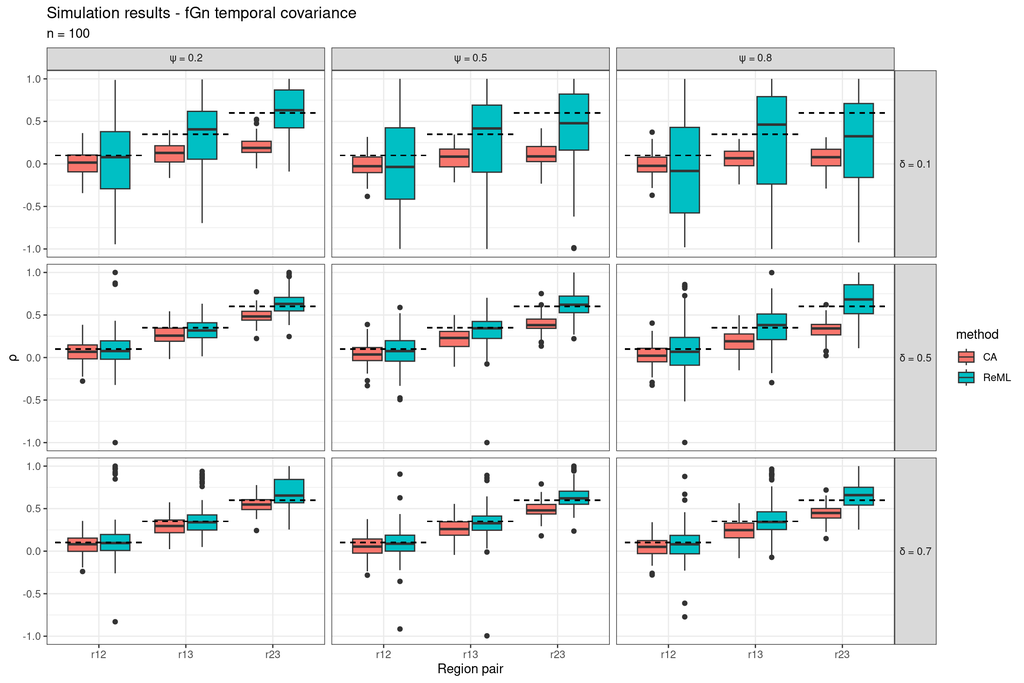

Temporal misspecification

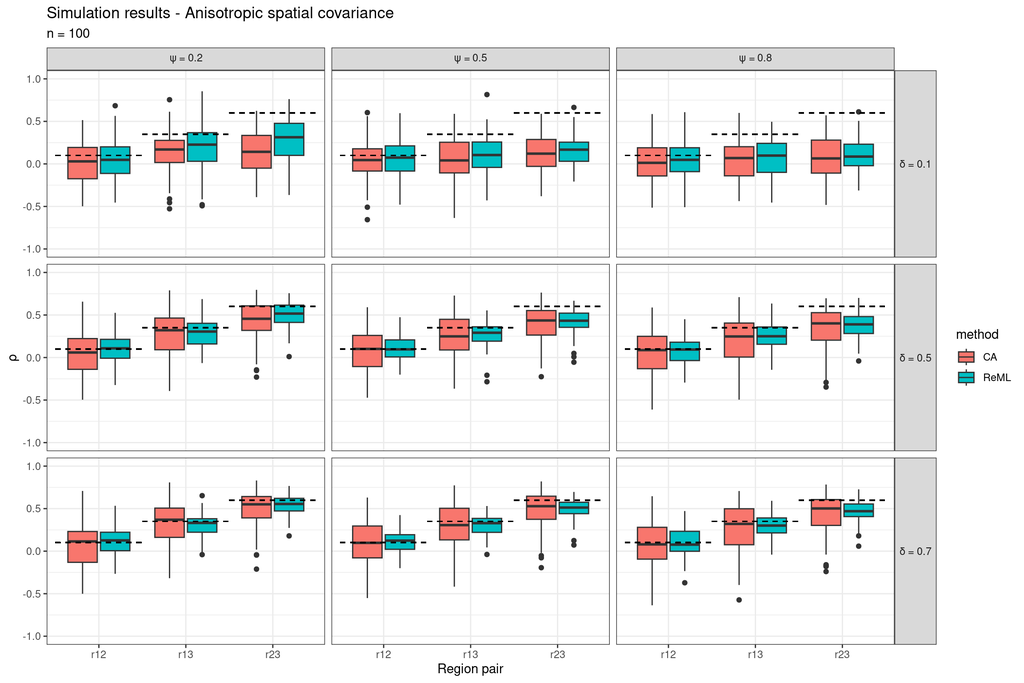

Spatial misspecification